# 看懂一條光譜， 就能抓出一次食品詐欺

這門課從零開始教你用 RamanSPy 讀懂食品的拉曼光譜。不需要程式基礎 —— 整頁的五個互動實驗台可以直接拉滑桿玩，每一段都附上對應的 Python 程式碼， 想動手再打開 Notebook。

**5**互動實驗台

**5**Jupyter Notebook

**6**光譜資料集

**30**題自動計分測驗

先玩玩看 ↓ 下載 Notebook

Big picture

## 食品分析為什麼要用拉曼光譜

拉曼光譜把食品裡的分子振動轉成一條「指紋」。不同成分 —— 脂肪、蛋白質、醣類、色素、添加物 —— 會讓特定波數區域變強或變弱，因此可用於快速篩檢、摻偽判別、品質監測與異物鑑別。

spectrum

### 🧬 像食品的條碼

每個樣品得到一條 intensity 對 Raman shift 的曲線。峰的位置對應分子的振動模式，跟雷射波長無關。

水干擾小

### 💧 不怕水

水的拉曼訊號極弱，乳品、飲料、生鮮可以直接測，不用乾燥或萃取。這是它勝過紅外光譜的最大優勢。

reproducible

### 🔁 流程可重現

RamanSPy 把讀檔、前處理、分析、繪圖整合成一致的介面，整套流程可以寫成一份能重跑的 Notebook。

### 跟紅外光譜比，該怎麼選

|  | 拉曼 | 紅外（IR / NIR） |
| --- | --- | --- |
| **選擇律** | 需**極化率**改變 | 需**偶極矩**改變 |
| **強訊號來自** | 非極性、對稱鍵：C=C、C–C、S–S、環呼吸 | 極性鍵：O–H、C=O、N–H |
| **水的干擾** | 極小 | 很大 |
| **樣品前處理** | 幾乎不用，可隔玻璃或塑膠袋測 | 常需研磨、壓片或 ATR 貼合 |
| **最大缺點** | 螢光背景；訊號本身很弱 | 水干擾；穿透深度淺 |

結論 拉曼與 IR 是**互補**的。IR 上很弱的 C=C（不飽和度）在拉曼上很強， 這正是拉曼特別適合**油脂**分析的原因；而不怕水讓它適合**乳品、飲料、生鮮**的現場快篩。

Principle

## 分子指紋是怎麼來的

用單一波長的雷射照樣品，絕大多數光子被**彈性散射**（Rayleigh），能量沒變。 但每一千萬個光子裡大約有一個會跟分子的振動交換能量，散射出來的光子能量變了 —— 這就是**拉曼散射**。

拉曼位移 (cm⁻¹) = 1/λ<sub>雷射</sub> − 1/λ<sub>散射</sub>

因為它是「差值」，所以**與雷射波長無關**：同一物質用 532 nm 或 785 nm 測，峰的位置一樣。 這也是拉曼光譜能建立通用資料庫、能跨儀器比對的原因。

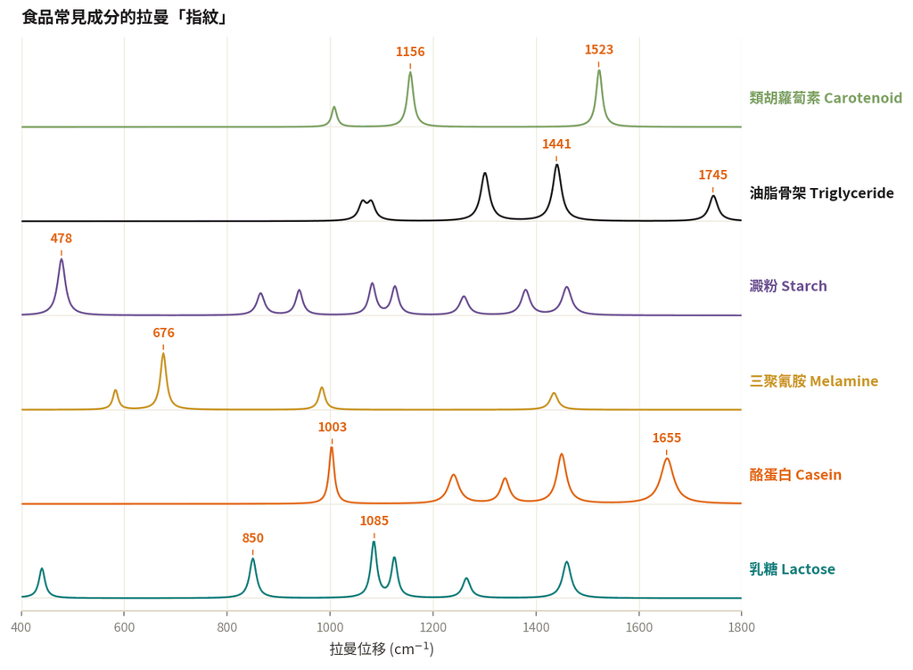

六種食品常見成分的拉曼指紋。判讀未知樣品時，就是拿它跟這些參考光譜比對。**478** 是澱粉、**676** 是三聚氰胺、**1523** 是類胡蘿蔔素。

### 兩個軸各代表什麼

- **X 軸：拉曼位移（cm⁻¹）** —— 對應「哪一種鍵在振動」。這是分子的身分證，位置固定。
- **Y 軸：強度（a.u.）** —— 大致對應「有多少」，但單位是**任意單位**。雷射功率、曝光時間、對焦深度都會改變它，所以**不同次量測的絕對強度不能直接比較**。

常見誤解 「A 樣品的 1085 峰高 3200，B 只有 1800，所以 A 的醣類比較多。」—— 錯。沒有歸一化、沒有內標，這兩個數字不能比。

互動實驗台 01

## 混合物的光譜＝各成分的疊加

食品是複雜混合物。把下面六種成分的比例拉一拉，看混出來的光譜長什麼樣， 以及程式自動找到的峰對應到哪一個分子。

拉滑桿

#### 合成光譜實驗室

試試看：先只留乳糖，再慢慢加入三聚氰胺 —— 注意 676 cm⁻¹ 什麼時候開始被偵測到。

乳糖（醣類）80%

酪蛋白（蛋白質）35%

澱粉0%

油脂0%

類胡蘿蔔素0%

三聚氰胺0%

[interactive chart not shown]

注意 把「類胡蘿蔔素」只拉到 5%，1523 cm⁻¹ 就已經很明顯了。 這是**共振拉曼增強（resonance Raman scattering, RRS）** —— 當雷射波長落在分子的電子吸收帶內，散射截面會放大數個數量級。類胡蘿蔔素是這個現象最經典的例子，1970 年就有人在完整的植物組織裡直接測到[1]。  
**沒有一個放諸四海的倍率**：增強程度取決於雷射與吸收帶的接近程度。有研究用 488、514、532、633 nm 分別激發 β-胡蘿蔔素，發現 488／514 nm 的共振增強最強，但 **532 nm 才是最佳選擇** —— 增強適中，同時螢光與自吸收都比較低[2]。這正是食品拉曼常用 532 nm 的原因。 所以**峰很強不等於含量很多**，要講濃度就一定得做檢量線。

對應程式碼 **NB1 · 建立光譜物件並畫出來**

```python
import pandas as pd
import ramanspy as rp

raw = pd.read_csv("data/milk_powder_raw_single.csv")
x = raw["raman_shift_cm-1"].values     # X 軸：拉曼位移
y = raw["intensity"].values            # Y 軸：強度

spectrum = rp.Spectrum(y, x)           # ⚠ 先強度、後波數，順序別寫反
rp.plot.spectra(spectrum, title="奶粉（原始光譜）")
rp.plot.show()
```

互動實驗台 02

## 前處理：五個步驟，順序不能亂

儀器直接吐出來的光譜有三個問題：螢光背景、宇宙射線尖峰、隨機雜訊。 **前處理沒做好，後面所有統計結果都是精美的垃圾。**

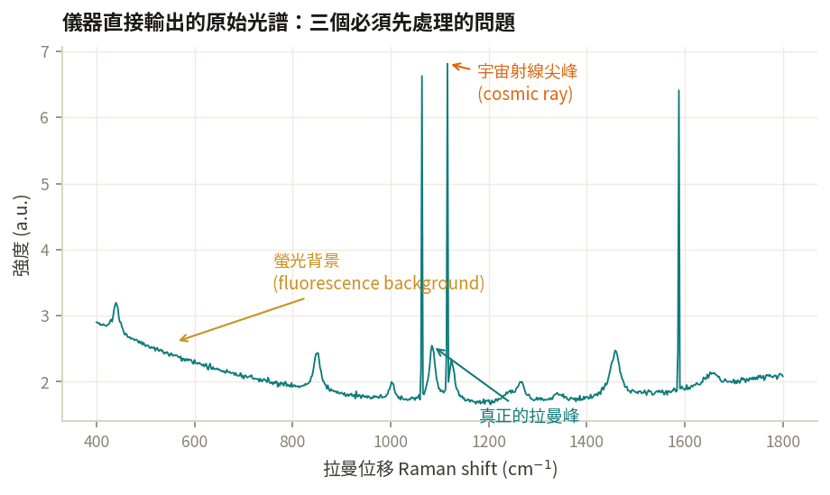

儀器直接輸出的光譜。真正的化學資訊只佔其中一小部分，其餘三個都是必須先處理掉的干擾。

1. **裁切 Cropper** 切掉兩端只有雜訊的區段，食品分析慣例留 400–1800 cm⁻¹ 的指紋區。
2. **去尖峰 WhitakerHayes** 真峰有寬度，宇宙射線只有 1–2 點寬。**必須排在平滑之前** —— 一旦被平滑抹成小丘，就再也刪不掉了。
3. **平滑 SavGol** 壓低雜訊。視窗開太大會把窄峰抹平，這是最常見的自傷。
4. **基線校正 IModPoly** 扣掉螢光背景。做過頭會把寬帶的真實峰（例如醯胺 I）也當背景減掉。
5. **歸一化 MinMax** 讓不同樣品可比較。**一定要放最後**，否則尺度又被後面的步驟改掉。

拉滑桿

#### 前處理實驗台

灰色虛線是處理前、湖綠是處理後。試試看：把平滑視窗拉到 41 點以上，盯著 676 cm⁻¹ 那個峰。

螢光背景強度1.8×

雜訊0.020

平滑視窗9 點

基線校正（去螢光）

歸一化 MinMax

[interactive chart not shown]

**—**1085 cm⁻¹ 乳糖峰

**—**676 cm⁻¹ 三聚氰胺峰

**—**676 峰的半高寬

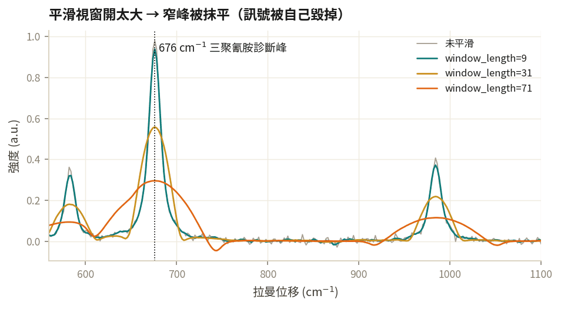

實用原則 平滑視窗涵蓋的波數範圍，要**明顯小於你要偵測的峰的半高寬**。 寧可留一點雜訊 —— 雜訊還能靠平均多條光譜壓下去，抹掉的峰救不回來。

對應程式碼 **NB2 · 把五個步驟串成一條 Pipeline**

```python
pipeline = rp.preprocessing.Pipeline([
    rp.preprocessing.misc.Cropper(region=(450, 1800)),               # ① 裁切
    rp.preprocessing.despike.WhitakerHayes(),                        # ② 去宇宙射線
    rp.preprocessing.denoise.SavGol(window_length=9, polyorder=3),   # ③ 平滑
    rp.preprocessing.baseline.IModPoly(),                            # ④ 基線校正
    rp.preprocessing.normalise.MinMax(),                             # ⑤ 歸一化
])

processed = pipeline.apply(spectra)   # 同一條 pipeline 直接套整批 60 個樣品
print(processed.spectral_data.shape)  # (60, 676) → (樣品數, 波數點數)
```

**基線校正方法怎麼挑？**

| 方法 | 特性 | 適用 |
| --- | --- | --- |
| `IModPoly()` | 多項式迭代，穩定、快、參數少 | 一般食品樣品（本課程預設） |
| `ASLS()` / `ASPLS()` | 懲罰最小平方，彈性大 | 背景形狀複雜、不像多項式時 |
| `AIRPLS()` | 自適應加權迭代 | 螢光極強、背景起伏大時 |

**已知地雷：**`normalise.AUC()` 在 NumPy 2.0 以上會拋出 `AttributeError: module 'numpy' has no attribute 'trapz'`，因為 `np.trapz` 已被移除。 本課程改用 `MinMax()` 或 `Vector()`。

互動實驗台 03

## 峰位判讀：食品分析師真正的價值

會跑程式的人很多，看得懂峰位代表什麼分子的人才值錢。這一段把光譜接回化學。

### 必背的食品特徵峰

| 波數 (cm⁻¹) | 振動歸屬 | 在食品裡代表 |
| --- | --- | --- |
| 478 | C–C–O / 環變形 | **澱粉**（診斷峰） |
| 676 | 三嗪環呼吸 | **三聚氰胺** — 三嗪環 ring breathing II [8,12] |
| 850 / 1085 / 1125 | C–C、C–O 伸縮 | 醣類（乳糖、蔗糖） |
| 1003 | 苯環呼吸（苯丙胺酸） | **蛋白質** — 強度穩定，常當內標 |
| 1156 / 1523 | C–C / C=C 共軛鏈 | **類胡蘿蔔素** — ν₂ / ν₁ 共振增強帶 [3,4] |
| 1265 | =C–H 面內變形（順式） | 油脂**不飽和度** |
| 1301 | CH₂ 扭曲 | 油脂飽和鏈 |
| 1441 | CH₂ 剪式變形 | 油脂總量 — 常當內標 |
| 1655 | C=C 伸縮 **或** 醯胺 I | 不飽和脂肪 **或** 蛋白質二級結構 |
| 1745 | C=O 伸縮（酯） | 三酸甘油酯 |

陷阱 **1655 cm⁻¹** 在油脂樣品裡是 C=C，在蛋白質樣品裡是醯胺 I。 同一個波數、兩種完全不同的歸屬 —— **不先確認基質是什麼，就不能判讀單一波數**。

動手判讀

#### 未知樣品判讀器

[interactive chart not shown]

對應程式碼 **NB3 · 讓程式自動找峰**

```python
ax, peaks, props = rp.plot.peaks(one_spectrum, prominence=0.05, return_peaks=True)
rp.plot.show()
print(peaks)      # → [ 676. 1003. 1085. 1441. ...]

# prominence 是「多凸才算一個峰」的門檻：
#   設太小 → 雜訊全被當成峰
#   設太大 → 小而重要的摻偽物峰被漏掉
# 實務做法：先看你關心的診斷峰有多高，把門檻設在它的一半以下。
```

互動實驗台 04

## 奶粉三聚氰胺篩檢：以及這個方法的極限

2008 年毒奶粉事件中，不肖業者加入三聚氰胺以虛增凱氏定氮法測到的「蛋白質」。 拉曼能不能當快篩？我們用 60 個樣品實際檢驗，並誠實回答它夠不夠格。

### 為什麼選 676 cm⁻¹

好的診斷峰要同時滿足兩個條件：**（一）它是目標物最強的峰；（二）基質在那裡沒有峰。** 三聚氰胺的三嗪環呼吸（ring breathing II）在 676 cm⁻¹，而奶粉基質（乳糖、酪蛋白）在此處剛好空白 —— 這叫**乾淨的分析視窗**。文獻上這個峰報導在 **674–685 cm⁻¹** 之間，指認為三嗪環的面內變形[11,12]；在 SERS 條件下會位移到 ~697–707 cm⁻¹，因為分子是以環上的氮吸附在銀表面、且吸附角度隨濃度改變[13]。比對資料庫時務必確認激發條件與是否用了增強基材。

拉滑桿

#### 摻偽偵測模擬器

左圖是 676 cm⁻¹ 附近的放大光譜，右圖的黑點是 60 個真實樣品的實測值。拉動濃度看什麼時候才會被判定「檢出」。

加入的三聚氰胺濃度0.00 %

[interactive chart not shown]

**—**676 cm⁻¹ 峰強度

**—**判定閾值（空白＋3SD）

**—**本方法偵測極限 LOD

**—**換算濃度

對應程式碼 **NB4 · 用空白樣品訂判定閾值**

```python
i676   = np.argmin(abs(axis - 676))
peak676 = X[:, i676]

blank     = peak676[meta.label == "normal"]      # 20 個空白樣品
threshold = blank.mean() + 3 * blank.std()       # 分析化學的標準做法
detected  = peak676 > threshold

lod = meta.melamine_pct[detected & (meta.melamine_pct > 0)].min()
print(f"判定閾值 = {threshold:.4f}")
print(f"實務偵測極限 LOD ≈ {lod:.2f} %")
```

這門課最重要的一段 我們算出 **LOD ≈ 0.5%**，也就是約 **5,000 mg/kg**。 而 Codex 對三聚氰胺的限量是：**粉狀嬰兒配方 1 mg/kg**、液態嬰兒配方 **0.15 mg/kg**、其他食品與飼料 **2.5 mg/kg**[14]。 **差距超過兩千倍。**

所以正確結論是：一般拉曼可以當**現場快篩**，抓出明目張膽的大量摻假； 但它**不能**取代 LC-MS/MS 這類法規確認方法。要逼近法規限值需要 **SERS（表面增強拉曼）**， 銀膠可達 10⁵ 倍以上的增強[9]，實測已能把牛奶中三聚氰胺的定量極限壓到 **0.5 µg/mL**[9]；用金奈米指狀基材甚至可在嬰兒配方中達到 **100 ppb（0.1 mg/kg）**，低於 FDA 的 1 ppm 容許值[10]。換句話說，**要達到法規限值，需要的不是更好的資料處理，而是換一種量測方式**。

**「未檢出」不等於「沒有」。**任何檢驗報告都必須同時標示方法的偵測極限，否則這句話沒有意義。

### PCA：不給答案，機器能自己看出什麼

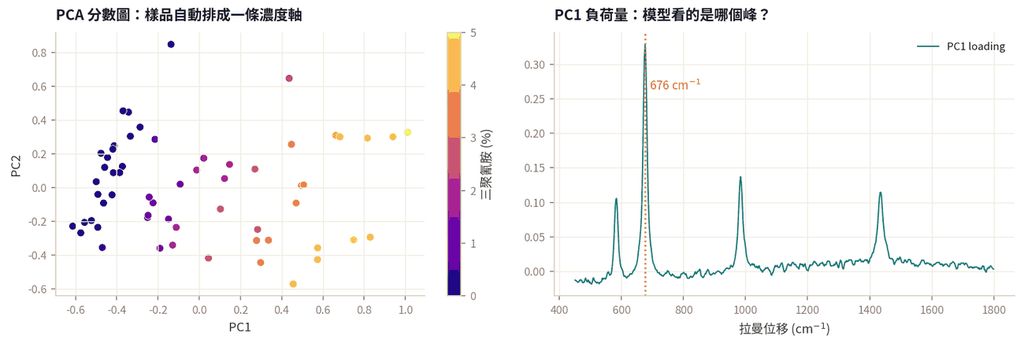

左：分數圖，樣品自動排成一條濃度軸（PC1 與濃度相關係數 0.99）。右：PC1 負荷量 —— **模型盯的正是 676 cm⁻¹**，化學上說得通。

專家第一個會問 分數圖分得開，不代表模型是對的 —— 它有可能抓到的是「兩組樣品在不同天量測」這種假訊號。**一定要看負荷量**，確認模型倚重的波數在化學上說得通。

對應程式碼 **NB4 · PCA 與分群**

```python
pca = rp.analysis.decompose.PCA(n_components=3)
projections, components = pca.apply(processed)
pc1, pc2, pc3 = projections          # ⚠ 回傳的是 list，projections[0] 才是 PC1 分數

# KMeans 回傳的是「到各群中心的距離」，不是標籤
distances, centers = rp.analysis.cluster.KMeans(n_clusters=2).apply(processed)
labels = np.argmin(np.array(distances), axis=0)
```

分群結果會把「正常品＋低濃度摻偽品」歸成一群，跟標籤對不起來。這不是演算法壞掉 —— KMeans 是**無監督**的，它只照光譜相似度分堆，而 0.2% 的樣品光譜本來就跟正常品幾乎一樣。 **分群對不上標籤，通常是在告訴你：這兩類在你量的訊號上本來就分不開。**

互動實驗台 05

## 定量：橄欖油裡摻了多少葵花油

橄欖油摻便宜油是全球最常見的食品詐欺之一。50 個樣品、摻入比例 0–50%， 這是典型的**多變量校正**問題，標準工具是 PLS 迴歸。

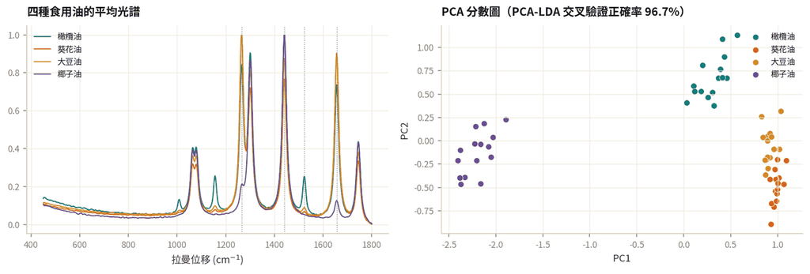

左：四種油的平均光譜，差異集中在 1265、1523、1656。右：PCA 分數圖，椰子油（飽和度最高）離群最遠。PCA-LDA 五折交叉驗證正確率 **96.7%**。

先試最簡單的 不動用任何機器學習，光是 **1265 / 1441 比值**（不飽和度指標） 就能分開大部分油品。簡單方法有效時，它更好解釋、更好轉移到別台儀器、也更好通過查核。

拉滑桿

#### PLS 潛在變數選擇器

PLS 只有一個關鍵決策：用幾個潛在變數。太少配適不足、太多過度配適。拉拉看，找 RMSECV 的最低點。

潛在變數個數LV = 4

[interactive chart not shown]

**—**RMSECV（交叉驗證誤差）

**—**R²

**—**實用偵測下限（≈3×RMSECV）

把數字翻譯成人話 RMSECV = 3.3% 代表誤差約 ±3.3 個百分點， 這個方法**無法可靠偵測 2% 的摻混**。實用偵測下限大約落在 RMSECV 的 3 倍，也就是 10% 左右 —— 抓得到大額摻假，抓不到少量摻混。這與文獻上一般拉曼（非 SERS）的表現是同一個數量級。

對應程式碼 **NB5 · 選 LV、建模、評估**

```python
from sklearn.cross_decomposition import PLSRegression
from sklearn.model_selection import cross_val_predict
from sklearn.metrics import mean_squared_error, r2_score

rmsecv = []
for n in range(1, 11):
    pred = cross_val_predict(PLSRegression(n_components=n), Xa, ya, cv=5).ravel()
    rmsecv.append(mean_squared_error(ya, pred) ** 0.5)

best_lv = int(np.argmin(rmsecv)) + 1      # → 4
pls = PLSRegression(n_components=best_lv).fit(Xa, ya)

# 絕對不能跳過：看模型倚重哪些波數
coef = pls.coef_.ravel()   # 大值應落在 1265 / 1523 / 1656 —— 真正的化學差異
```

模型不會說「我不知道」 把一個奶粉樣品丟進油品分類器，它一樣會硬選一種油， 而且可能給出很高的信心值。實務上必須加上**適用範圍（applicability domain）**檢查 —— 光譜殘差過大或馬氏距離超出訓練集範圍時，回報「超出模型適用範圍」而不是給答案。

Full script

## 完整程式碼：不開 Colab 也能讀完

上面每一段都附了片段。這裡把整條流程接起來 —— 從讀檔到出結果，共 40 行。 看懂這 40 行，這門課的技術部分就結束了。

```python
import numpy as np
import pandas as pd
import ramanspy as rp
from sklearn.cross_decomposition import PLSRegression
from sklearn.model_selection import cross_val_predict
from sklearn.metrics import mean_squared_error

# ---------- 1. 讀檔 ----------
def load_spectra(path):
    """CSV：每列一個樣品，欄名就是波數 → (樣品資訊, 光譜物件)"""
    df = pd.read_csv(path)
    meta_cols = [c for c in df.columns if not c.replace(".", "", 1).isdigit()]
    axis = np.array([float(c) for c in df.columns if c not in meta_cols])
    return df[meta_cols], rp.SpectralContainer(df.drop(columns=meta_cols).values, axis)

meta, spectra = load_spectra("data/milk_powder_melamine.csv")

# ---------- 2. 前處理 ----------
pipeline = rp.preprocessing.Pipeline([
    rp.preprocessing.misc.Cropper(region=(450, 1800)),
    rp.preprocessing.despike.WhitakerHayes(),
    rp.preprocessing.denoise.SavGol(window_length=9, polyorder=3),
    rp.preprocessing.baseline.IModPoly(),
    rp.preprocessing.normalise.MinMax(),
])
processed = pipeline.apply(spectra)
X, axis = processed.spectral_data, processed.spectral_axis

# ---------- 3. 定性：診斷峰 + 判定閾值 ----------
peak676   = X[:, np.argmin(abs(axis - 676))]
blank     = peak676[meta.label == "normal"]
threshold = blank.mean() + 3 * blank.std()
print("檢出樣品數：", int((peak676 > threshold).sum()))

# ---------- 4. 探索：PCA ----------
projections, components = rp.analysis.decompose.PCA(n_components=2).apply(processed)
pc1, pc2 = projections

# ---------- 5. 定量：PLS ----------
ameta, aspectra = load_spectra("data/olive_adulteration.csv")
Xa = pipeline.apply(aspectra).spectral_data
ya = ameta.sunflower_pct.values

pred  = cross_val_predict(PLSRegression(n_components=4), Xa, ya, cv=5).ravel()
rmsecv = mean_squared_error(ya, pred) ** 0.5
print(f"RMSECV = {rmsecv:.2f} %")
```

step 1

### 讀懂就好

第一次讀不用每行都懂。先抓住五個區塊的名字：讀檔、前處理、定性、探索、定量。

step 2

### 再動手改

打開 Notebook，把 `window_length`、`n_components` 改一個數字再跑，看結果怎麼變。

step 3

### 最後自己寫

換一組資料、換一個診斷峰，重跑同一條流程。能做到這一步就算學會了。

Hands-on

## 五本 Notebook 與課程資料

每一本約 50–70 分鐘，採「逐格執行」設計，每格只做一件事，程式碼旁邊用中文說明為什麼要做。 遇到 `👉 換你做` 就停下來改一個參數再跑一次。結尾都有自我檢核題與參考答案。

NB1

### 第一條光譜

從完全不會 Python 開始，把一條奶粉光譜讀進來、畫出來，並看懂它為什麼「很醜」。

在 Colab 開啟 ↗NB1_intro_spectrum.ipynb

NB2

### 前處理

五個步驟逐一拆解，示範做過頭會怎樣，最後用 Pipeline 一次處理 60 個樣品。

在 Colab 開啟 ↗NB2_preprocessing.ipynb

NB3

### 峰位判讀

特徵峰對照表、自動找峰、共振增強，以及六個未知樣品的判讀實作。

在 Colab 開啟 ↗NB3_peak_assignment.ipynb

NB4

### 奶粉摻偽篩檢

判定閾值、偵測極限、PCA 與 KMeans，以及與法規限量的落差討論。

在 Colab 開啟 ↗NB4_melamine_screening.ipynb

NB5

### 油品鑑別與定量

PCA-LDA 分類、PLS 定量、交叉驗證，以及模型適用範圍的檢查。

在 Colab 開啟 ↗NB5_oil_authentication.ipynb

暖身

### 入門暖身本（舊版保留）

用模擬的澱粉型／高蛋白型／摻脂型光譜快速走一遍 PCA 分群，適合第一堂課暖身。

在 Colab 開啟 ↗ramanspy_food_beginner.ipynb

### 課程資料集

| 檔名 | 內容 | 用在 |
| --- | --- | --- |
| `milk_powder_raw_single.csv` | 一條未處理的奶粉光譜（含螢光、尖峰、雜訊） | NB1、NB2 |
| `reference_spectra.csv` | 六種純物質參考光譜 | NB3 |
| `milk_powder_melamine.csv` | 60 個奶粉樣品，三聚氰胺 0–5% | NB2、NB4 |
| `edible_oils.csv` | 60 個油品樣品：橄欖、葵花、大豆、椰子各 15 | NB3、NB5 |
| `olive_adulteration.csv` | 50 個橄欖油摻葵花油樣品，0–50% | NB5 |
| `unknown_samples.csv` | 6 個未知樣品（期末判讀用） | NB3、NB5、期末 |

關於資料 這些是**依文獻峰位建立的模擬光譜**，刻意加入螢光背景、宇宙射線與雜訊， 讓你在教室裡就能遇到真實儀器會出的狀況，同時濃度與答案完全可控、方便驗算。 課程結論（偵測極限、模型誤差）與真實文獻報告的數量級一致。

去做線上測驗 → [GitHub 原始檔](https://github.com/Tai-ShengYeh/Tai-ShengYeh.github.io/tree/main/ramanspy-food-analysis)

Data provenance

## 數據從哪裡來

這一節必須講清楚，因為它決定你能用這些數字說到什麼程度。

最重要的一句 本課程 `data/` 裡的六組光譜**全部是依文獻峰位建立的模擬資料， 不是實測光譜**。它們用來教流程與判讀邏輯；**不可以引用為實驗證據**，也不能拿來寫報告的數據來源。

### 怎麼生成的

1. **純物質骨架** 每個成分用一組 Lorentzian 峰疊出來，峰位取自下表的文獻值，半高寬 8–25 cm⁻¹、 相對強度依文獻描述的強弱關係設定。
2. **混合** 按濃度線性疊加（拉曼在稀薄混合物中對濃度近似線性），三聚氰胺另乘上一個散射截面係數。
3. **加上儀器的毛病** 螢光背景用 `0.9·e−2.2t + 0.5t² + 0.25` 的經驗式， 再隨機插入 0–2 根寬度 1–2 點的宇宙射線尖峰，最後加高斯雜訊（σ ≈ 0.012–0.02）。
4. **樣品間變異** 每個樣品的成分係數再乘上一個小的隨機擾動，模擬批次差異。

完整程式在 `make_data.py`，亂數種子固定（`20260801`），任何人重跑都會得到同一組資料。

### 峰位的文獻依據

| 成分 | 使用的峰位 (cm⁻¹) | 依據 |
| --- | --- | --- |
| **類胡蘿蔔素** | 1008 (ν₃)、1156 (ν₂)、1523 (ν₁) | [3][4][6] |
| **油脂骨架** | 1063、1080、1301、1441、1745 | [6] |
| **不飽和度** | 1265 (=C–H)、1656 (C=C) | [6][7] |
| **三聚氰胺** | 583、676、984、1435 | [8][11][12] |
| **乳糖 / 醣類** | 355、440、850、1085、1125、1265、1460 | [16] |
| **酪蛋白 / 蛋白質** | 1003 (Phe)、1240 (醯胺 III)、1450、1655 (醯胺 I) | [16] |
| **澱粉** | 478、865、940、1082、1126、1260、1380、1460 | [16] |

### 結果對得上文獻嗎

| 本課程算出的 | 數值 | 文獻上同類方法的量級 |
| --- | --- | --- |
| 三聚氰胺 LOD（一般拉曼） | **≈ 0.5%（5,000 mg/kg）** | 一般拉曼可在奶粉中辨識 1% 的三聚氰胺 [8]；要到 mg/kg 級需 SERS [9][10][11] |
| 四種食用油分類正確率 | **96.7%**（PCA-LDA，5 折 CV） | 橄欖油品種／種類判別常報 90–100% [6] |
| 橄欖油摻混定量 | **RMSECV 3.26%、R² 0.952**（PLS, LV=4） | 拉曼＋PLS 對摻混比例的預測誤差多在數個百分點 [7] |

量級一致，但這是**設計出來的一致** —— 因為模擬時就把雜訊與變異調到那個範圍。 它證明的是「這條流程會給出合理的數字」，不是「拉曼真的能做到這個數字」。

想用真資料 RamanSPy 內建了幾組公開資料集可以直接呼叫，例如 `rp.datasets.rruff()`（RRUFF 礦物拉曼資料庫）與 `rp.datasets.bacteria()`； 食品類的公開光譜可查 Mendeley Data、Zenodo 與各校的 open data 平台。 做專題時請改用實測或公開實測資料，本課程資料僅供教學演練。

References

參考文獻

共振拉曼增強

1. Gill, D.; Kilponen, R. G.; Rimai, L. *Resonance Raman Scattering of Laser Radiation by Vibrational Modes of Carotenoid Pigment Molecules in Intact Plant Tissues*. **Nature** 1970, 227(5259), 743–744. [doi:10.1038/227743a0](https://doi.org/10.1038/227743a0) —— 最早在完整植物組織中直接觀測到類胡蘿蔔素的共振拉曼訊號；激發波長落在電子吸收帶內時，散射效率大幅提升到足以克服吸收損失。

2. Lu, L.; Shi, L.; Secor, J.; Alfano, R. *Resonance Raman scattering of β-carotene solution excited by visible laser beams into second singlet state*. **J. Photochem. Photobiol. B** 2018, 179, 18–22. [doi:10.1016/j.jphotobiol.2017.12.022](https://doi.org/10.1016/j.jphotobiol.2017.12.022) —— 以 488／514／532／633 nm 比較 β-胡蘿蔔素的共振增強並校正自吸收；488／514 nm 增強最強，但 **532 nm 為最佳折衷**（螢光與自吸收較低）。本課程採 532 nm 的依據。

3. Withnall, R.; Chowdhry, B. Z.; Silver, J.; Edwards, H. G. M.; de Oliveira, L. F. C. *Raman spectra of carotenoids in natural products*. **Spectrochim. Acta A** 2003, 59(10), 2207–2212. doi:10.1016/S1386-1425(03)00064-7 —— ν₁（C=C，1400–1600）與 ν₃ 強烈增強；ν₁ 位置隨共軛雙鍵數增加而往低波數移動，可用來推估共軛鏈長。

4. de Oliveira, V. E.; Castro, H. V.; Edwards, H. G. M.; de Oliveira, L. F. C. *Carotenes and carotenoids in natural biological samples: a Raman spectroscopic analysis*. **J. Raman Spectrosc.** 2010, 41(6), 642–650. [doi:10.1002/jrs.2493](https://doi.org/10.1002/jrs.2493) —— β-胡蘿蔔素三個特徵帶 1515、1156、1008 cm⁻¹。**特別注意**：作者明確警告，類胡蘿蔔素與基質的分子交互作用會使 C=C 帶明顯位移，因此「拿標準品光譜直接比對就下結論」在真實生物樣品上是危險的 —— 這正是本課程反覆強調「先確認基質」的文獻依據。

5. Le Ru, E. C.; Auguié, B. *Enhancement Factors: A Central Concept during 50 Years of Surface-Enhanced Raman Spectroscopy*. **ACS Nano** 2024, 18(14), 9773–9783. [doi:10.1021/acsnano.4c01474](https://doi.org/10.1021/acsnano.4c01474) —— 增強因子的定義、平均值與最大值的差異、熱點分布與量測方式。引用任何「增強幾倍」的數字前建議先讀這一篇。

食用油與橄欖油

6. Portarena, S.; Anselmi, C.; Zadra, C.; Farinelli, D.; Famiani, F.; Baldacchini, C.; Brugnoli, E. *Cultivar discrimination, fatty acid profile and carotenoid characterization of monovarietal olive oils by Raman spectroscopy at a single glance*. **Food Control** 2019, 96, 137–145. [doi:10.1016/j.foodcont.2018.09.011](https://doi.org/10.1016/j.foodcont.2018.09.011) —— 特級初榨橄欖油特徵帶：965、1004、1081、1156、1301、1440、1523、1656、1748 cm⁻¹（514.5 nm 激發，與類胡蘿蔔素共振）。

7. Chen, Y.; Yang, Z.; Zeng, S.; Tian, H.; Cheng, Q.; Lv, S.; Li, H. *Quantitative analysis of β-carotene and unsaturated fatty acids in blended olive oil via Raman spectroscopy combined with model prediction*. **Food Chemistry** 2025, 470, 142621. [doi:10.1016/j.foodchem.2024.142621](https://doi.org/10.1016/j.foodchem.2024.142621) —— 以 1156、1265、1526、1658 cm⁻¹ 配合模型預測橄欖油／葵花油摻混比例。與本課程 NB5 的作法相同，可作為 PLS 迴歸係數落點的對照。

三聚氰胺：一般拉曼、SERS 與法規

8. Schmidt, W.; Broadhurst, C. L.; Qin, J.; et al. *Continuous Temperature-Dependent Raman Spectroscopy of Melamine and Structural Analog Detection in Milk Powder*. **Appl. Spectrosc.** 2015, 69(3), 398–406. [doi:10.1366/14-07600](https://doi.org/10.1366/14-07600) —— **不用 SERS**，以一般拉曼在奶粉中辨識 1% 的三聚氰胺（及尿素、縮二脲、三聚氰酸）。本課程算出的 LOD ≈ 0.5% 與這個量級相符。

9. Zhang, X.; Zou, M.; Qi, X.; et al. *Detection of melamine in liquid milk using surface-enhanced Raman scattering spectroscopy*. **J. Raman Spectrosc.** 2010, 41(12), 1655–1660. [doi:10.1002/jrs.2629](https://doi.org/10.1002/jrs.2629) —— 銀膠達 10⁵ 倍以上增強；標準品 LOD 0.01 µg/mL，牛奶中定量極限 0.5 µg/mL，結果與 LC-MS/MS 相當。

10. Kim, A.; Barcelo, S. J.; Williams, R. S.; Li, Z. *Melamine Sensing in Milk Products by Using Surface Enhanced Raman Scattering*. **Anal. Chem.** 2012, 84(21), 9303–9309. [doi:10.1021/ac302025q](https://doi.org/10.1021/ac302025q) —— 金奈米指狀基材配可攜式拉曼儀，水中 LOD 120 ppt、嬰兒配方中 100 ppb，**低於 FDA 的 1 ppm 容許值**。

11. Wang, S.; Zhao, Y.; Wei, X.; et al. *Facile SERS screening of melamine in bovine milk with 2D printed AgNPs/glass fabric filter paper as the flexible substrate*. **Food Sci. Hum. Wellness** 2024, 13(5), 2595–2600. [doi:10.26599/fshw.2022.9250208](https://doi.org/10.26599/fshw.2022.9250208) —— 診斷訊號在 **674 cm⁻¹**，LOD 1.95×10⁻⁵ mg/mL，遠低於歐美 2.5×10⁻³ mg/mL 的安全限值。（開放取用）

12. Cheng, J.; Wang, S.; Su, X. *Detection of Melamine in Feed Using Liquid-Liquid Extraction Treatment Combined with Surface-Enhanced Raman Scattering Spectroscopy*. **PLoS ONE** 2014, 9(9), e107770. [doi:10.1371/journal.pone.0107770](https://doi.org/10.1371/journal.pone.0107770) —— 明確指認 ring breathing II 模式為三嗪環的面內變形。（開放取用）

13. Chen, X.; Hu, Y.; Gao, J.; et al. *Interaction of Melamine Molecules with Silver Nanoparticles Explored by SERS and Density Functional Theory Calculations*. **Appl. Spectrosc.** 2013, 67(5), 491–497. [doi:10.1366/12-06838](https://doi.org/10.1366/12-06838) —— 三聚氰胺以環上氮吸附於銀表面，且傾角隨濃度改變 —— 這是 SERS 條件下峰位會位移的原因。

14. FAO / WHO Codex Alimentarius Commission. *General Standard for Contaminants and Toxins in Food and Feed*, **CXS 193-1995**. —— 三聚氰胺最大限量：粉狀嬰兒配方 1 mg/kg、其他食品與飼料 2.5 mg/kg（2010 年通過）；液態嬰兒配方 0.15 mg/kg（2012 年通過）。

方法與工具

15. Georgiev, D.; Pedersen, S. V.; Xie, R.; Fernández-Galiana, Á.; Stevens, M. M.; Barahona, M. *RamanSPy: An Open-Source Python Package for Integrative Raman Spectroscopy Data Analysis*. **Anal. Chem.** 2024, 96(21), 8492–8500. [doi:10.1021/acs.analchem.4c00383](https://doi.org/10.1021/acs.analchem.4c00383) · [GitHub](https://github.com/barahona-research-group/RamanSPy)（開放取用，CC-BY）

16. 一般食品成分的拉曼歸屬（醣類 C–C／C–O 伸縮、蛋白質苯丙胺酸 1003 與醯胺 I／III、澱粉 478）採用食品拉曼光譜教科書與綜述的常用歸屬表。授課時建議請學生自行比對 RRUFF 或儀器廠商的標準品資料庫，確認自己手上儀器的實際峰位。

17. 前處理演算法：Savitzky–Golay 平滑；Whitaker–Hayes 去尖峰；ModPoly / asPLS / airPLS 基線校正。實作與參數說明見 RamanSPy 文件。

核對方式 本頁 [1]–[15] 的書目資料於 2026 年 8 月以 **scite** 逐筆查核（DOI、期刊、卷期、頁碼、作者），並以 **Consensus** 搜尋補齊共振拉曼增強的原始文獻。凡查不到同儕審查來源的說法（例如原先引用的專書章節與雜誌專欄）已改引可查核的期刊論文。

給學生的提醒 寫報告引用峰位時，**要引原始文獻，不要引這一頁**。 同一個官能基在不同基質、不同激發波長下的峰位會有數個 cm⁻¹ 的差異， 務必確認你引的文獻用的是什麼樣品、什麼雷射。

教師備註 建議三週進度：第 1 週原理＋NB1、NB2；第 2 週峰位判讀＋NB3＋未知樣品分組討論； 第 3 週 NB4、NB5，以 LOD 與法規限量的落差做結論討論。評量建議：Notebook 執行截圖 30%、線上測驗 30%、 未知樣品判讀報告 40%（推理過程重於答對與否）。